# Uygulama Notları: 4

## Bir ipte iki cambaz (II)

$y=x$ ve $y=x^2$ fonksiyonlarının grafiklerini $x \in [-10,10]$ aralığında çizdirmeyi deneyelim:

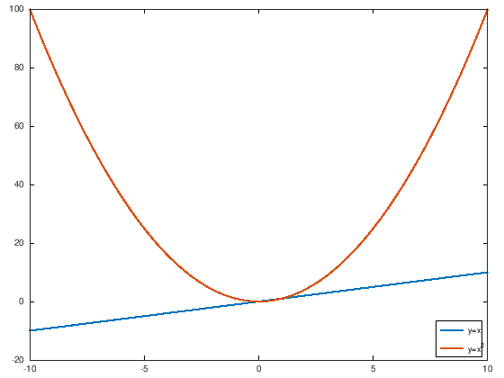

```matlab
x = linspace(-10,10,250);
y_1 = x;
y_2 = x.**2;
plot(x,y_1,"linewidth",4,x,y_2,"linewidth",4)
legend("y=x","y=x^2","location","southeast")
```

Bu grafikteki sorun nedir? $x$ 0 ile 1 arasındayken iki grafiğin değerleri gayet güzel anlaşıyorlardı fakat aralık artınca, değerler arasındaki farklar da uçtu gitti, bu nedenle $y_2 = x^2$ fonksiyonu baskın hale gelip, $y_1 =x$ fonksiyonunu gölgeledi. Bu türden, farklı değer aralıklarına sahip fonksiyonları birlikte gösterebilmek için, iki farklı düşey eksen kullanmamızı sağlayan `plotyy()` fonksiyonu ile çizim yaparız:

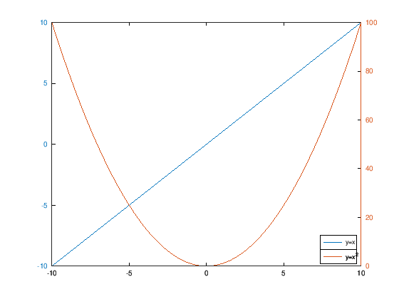

```matlab
x = linspace(-10,10,250);
y_1 = x;
y_2 = x.**2;
plotyy(x,y_1,x,y_2)
legend("y=x","y=x^2","location","southeast")
```

## Çok ipte çok cambaz

Artık grafik çizmeyi epey epey öğrendiğimize göre, aynı grafik tuvali üzerinde farklı grafikleri sıralamayı da görebiliriz. Bu sıralama işini `subplot()` komutu ile tanımlıyoruz.

Gözünüzün önüne (2x2)'lik bir matris getirin, örneğin:

$$ \begin{bmatrix}1&2\\3&4\end{bmatrix}$$

olsun.

Matrise bir isim vermediğimizden, bir yeri belirtmek için, her seferinde matrisin boyutunu ve yerin indisini belirtiriz. Mesela sağ alt köşedeki elemanı belirtmek için "2'ye 2'lik bir matrisi gözünüzün önüne getirip, onun 4. elemanının yerini düşünün" demek gibi. İşte `subplot()`'un parametreleri de bu şekilde çalışıyor. Her birini ayrı ayrı belirtip, oraya ne koyacağımızı tanımlıyoruz sonra. Aşağıdaki örneklere bakarsanız çok daha açıklayıcı olacağını umut ediyorum:

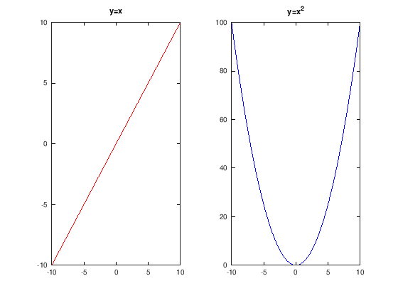

```matlab
# 1x2'lik bir düzen

subplot(1,2,1)
    # 1x2'lik matrisin 1. elemanı, yani soldaki penceredeyiz
    plot(x,y_1,"-r")
    title("y=x")
subplot(1,2,2)
    # şimdi 1x2'lik matrisin 2. elemanı, yani sağ penceredeyiz
    plot(x,y_2,"-b")
    title("y=x^2")
```

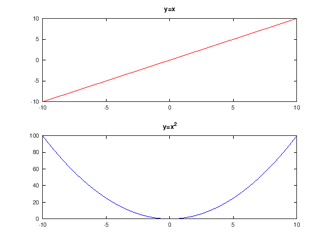

```matlab
# 2x1'lik bir düzen

subplot(2,1,1)
    # 2x1'lik matrisin 1. elemanı, yani yukarıdaki penceredeyiz
    plot(x,y_1,"-r")
    title("y=x")
subplot(2,1,2)
    # şimdi 1x2'lik matrisin 2. elemanı, yani aşağıdaki penceredeyiz
    plot(x,y_2,"-b")
    title("y=x^2")
```

*İlle de bütün hücreler dolacak* diye bir kural da yok bu arada:

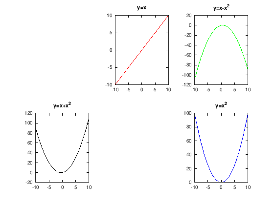

```matlab
# 2x3'lük bir düzen

subplot(2,3,2)
    # 2x3'lik matrisin 2. elemanı, yani yukarı satır, orta sütun
    plot(x,y_1,"-r")
    title("y=x")
subplot(2,3,3)
    # 2x3'lük matrisin 3. elemanı, yani sağ-üst hücre
    plot(x,y_1-y_2,"-g")
    title("y=x-x^2")
subplot(2,3,4)
    # 2x3'lük matrisin 4. elemanı, yani sol-alt hücre
    plot(x,y_1+y_2,"-k")
    title("y=x+x^2")
subplot(2,3,6)
    # şimdi 2x3'lük matrisin 6. elemanı, yani sağ-alt hücre
    plot(x,y_2,"-b")
    title("y=x^2")
```

# Saçılım

Yukarıdaki örneklerdeki verilerimiz hep sıralı verilerdi, yani noktalarımızı art arda çizgilerle birleştirince anlamlı bir şekil elde ediyor, gelişim sürecini izleyebiliyorduk. Fakat saçılma deneyleri gibi deneylerde (ya da elinizdeki vişne suyu dolu bardağı beyaz halıya düşürdüğünüzde oluşan desenler gibi kazalarda) bu şekilde bir sıralılık aranmaz. Bu tür durumlarda, `plot` yerine `scatter` fonksiyonunu kullanmak birtakım avantajlar (farklı şekilde büyüklük ve renklendirme yapabilmek gibi) sunar.

Saçılım için genelde çok fazla veriye ihtiyaç duyulur. Vişne bardağımızı kare şeklinde halımızın tam ortasına düşürdüğümüzü ve 300 adet damlanın rastgele yönlere sıçradığını varsayalım.

## Rastgele sayılar

Rastgele işlemler için `rand()` komutunu kullanırız, bize bu haliyle 0 ile 1 (0 dahil, 1 hariç) arasında eşit olasılıkla rastgele bir sayı üretir (düzgün dağılım):

```matlab
# Hesaplara başlamadan...
rand("seed",219) # Bu şekilde her seferinde aynı "rastgele" sayıların
                 # çıkmasını sağlıyoruz (yani sizin ürettiğiniz sayıların
                 # bu ders notundakilerle aynı olmasını)
```

```matlab
rand()
```

```
ans =  0.65708
```

```matlab
rand()
```

```
ans =  0.014786
```

boyut bildirirsek, o boyuttaki bir matrisi rastlantısal sayılarla doldurur:

```matlab
rand(3,5)
```

```
ans =

   0.15056   0.44253   0.64676   0.96474   0.74250
   0.51622   0.57650   0.30993   0.31049   0.49251
   0.22114   0.43923   0.45263   0.42314   0.14048
```

```matlab
# -2 ile 2 arasında rastgele sayılar:
rand(3,5)*4-2
```

```
ans =

  -1.36827   1.89567  -0.66630   1.66031   0.90189
   0.98473   1.92246   1.38515  -1.44258   1.41858
   0.35271  -0.24558  -1.34027   1.20135   0.69483
```

Halımızın merkezini (0,0), boyunu da 4x4 $m^2$ alırsak, üzerine rastgele şekilde dökülen 10 damlanın konumlarını (x,y) cinsinden şu şekilde üretebiliriz:

```matlab
damlalar = rand(10,2)*4-2
```

```
damlalar =

  -1.852137   0.978591
  -1.012549   0.364333
  -0.274938   1.093289
  -0.407501  -1.564739
   0.108775   0.753838
   0.759887  -1.285785
   0.884586  -1.492475
  -1.409493  -0.092157
  -1.501641  -0.610016
   0.305351  -1.798407
```

Çizdirmek için `scatter`'ı kullanalım:

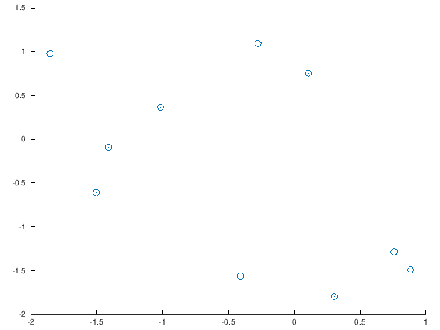

```matlab
scatter(damlalar(:,1),damlalar(:,2),500)
```

Yukarıdaki "500" parametresi boyla orantılı bir değer.

Damla sayısını 300'e çıkaralım:

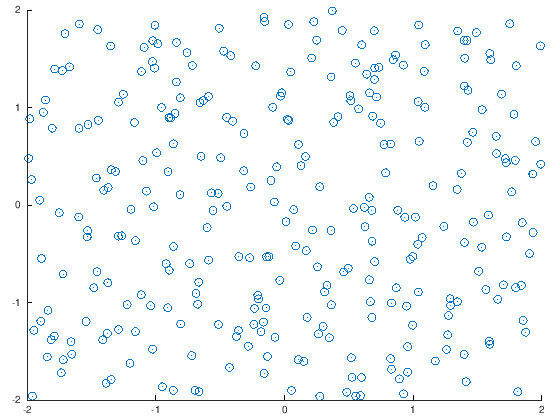

```matlab
damlalar = rand(300,2)*4-2;
scatter(damlalar(:,1),damlalar(:,2),500)
```

Kar beyaz halının ortasına dökülen vişne suyunun damlacıklarının konumu için düzgün dağılım çok da gerçekçi değil bu arada, sonuçta tahmin edebilirsiniz ki, *normalde* halının merkezine yakın düşen damlacıkların sayısı (/yoğunluğu) halının uçlarına kadar ulaşan damlacık sayısından (/yoğunluğundan) çok daha fazla olacaktır.

Burada "normalde" terimi anahtar kelimemiz. Doğada pek çok kez gözlemlediğimiz, belli bir ortalama değerin etrafında gerçekleşen dağılımlar için "normal dağılım"ı kullanıyoruz (*Gauss dağılımı* olarak da bilinir), bunu da `rand` yerine, `randn` fonksiyonunu kullanarak yapıyoruz. (normal dağılımı bütün güzellikleri ve formüler gösterimi ile birlikte "FİZ316 - İstatistik Fizik" dersinizde göreceksiniz 8):

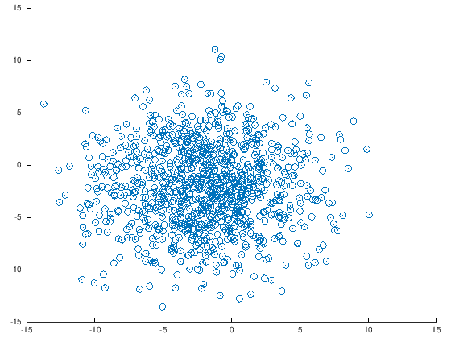

```matlab
damlalar = randn(1000,2)*4-2;
scatter(damlalar(:,1),damlalar(:,2),500)
```

### Bonus / Ekstra / Tercihe Bağlı

(istemeyen okumasın! ;)

`scatter`ın `plot`dan farkını, renk ve boy çeşitlemeleri yapabilmek olarak belirtmiştik. Her bir veri noktasının boyunu da, rengini de tek tek belirleyebiliriz.

Yukarıdaki örnekte boyu 500 almıştık, onun yerine 1. noktanın boyunu 1, ikincisinin 2, ..., 1000.sininkini 1000 alalım:

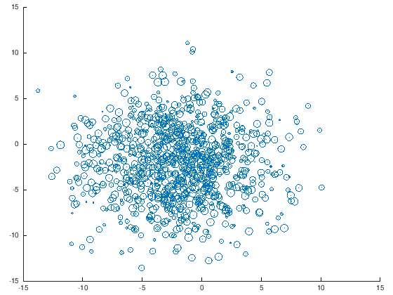

```matlab
scatter(damlalar(:,1),damlalar(:,2),1:1000)
```

Çok mantıklı bir şey değil ama fikir veriyor. Peki örneğin merkeze ne kadar uzaksa o kadar küçük olsun? Nasıl yaparız?

Önce merkeze olan mesafelerini hesaplarız. Elimizde her bir damlanın x ve y koordinatları olduğuna göre, karelerinin toplamının kökü, ya da daha doğrudan koordinatların `norm`u bize mesafeleri verir:

```matlab
# ilk 10 damlanın koordinatları:
damlalar(1:10,:)

# Kötü yoldan hesaplanmış mesafeler vektörünün ilk 10 elemanı:
mesafeler_kotu = (damlalar(:,1).**2 + damlalar(:,2).**2).**0.5;
mesafeler_kotu(1:10)

# Güzel yoldan hesaplanmış mesafeler vektörünün ilk 10 elemanı:
mesafeler_guzel = norm(damlalar,"rows");
mesafeler_guzel(1:10)
```

```
ans =

   4.458101  -1.958335
  -1.009483  -4.639653
  -1.456757  -1.501038
  -0.092184  -2.475710
  -2.907051  -0.344995
  -1.664433   1.439826
  -2.764086   1.477501
   4.645195  -0.194080
  -1.197024  -3.200934
   1.041247  -7.869998

ans =

   4.8693
   4.7482
   2.0917
   2.4774
   2.9275
   2.2008
   3.1342
   4.6492
   3.4174
   7.9386

ans =

   4.8693
   4.7482
   2.0917
   2.4774
   2.9275
   2.2008
   3.1342
   4.6492
   3.4174
   7.9386
```

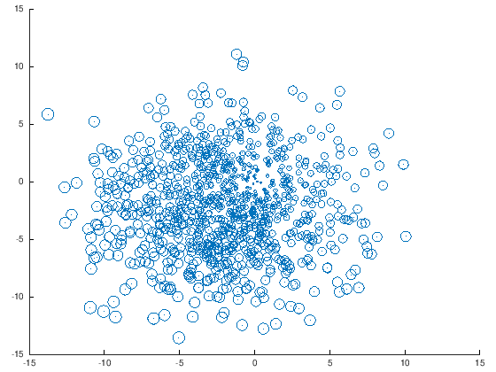

```matlab
scatter(damlalar(:,1),damlalar(:,2),mesafeler_guzel*100)
```

Neredeyse olacak gibi -- yukarıdakinde uzaklaştıkça büyüyorlar, halbuki biz uzaklaştıkça küçülmelerini istiyoruz, o halde:

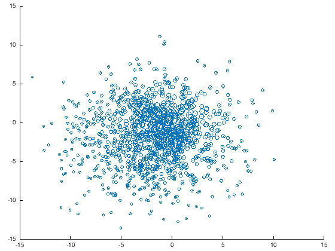

```matlab
scatter(damlalar(:,1),damlalar(:,2),(1./mesafeler_guzel)*1500)
```

Renkleri içeriden dışarıya açalım, içlerini de doldularalım...

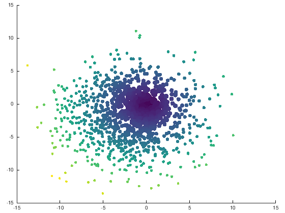

```matlab
scatter(damlalar(:,1),damlalar(:,2),...
       (1./mesafeler_guzel)*1500,...
       mesafeler_guzel,"filled")
```

# Histogram

Histogram grafikleri dağılımları gösteren türden grafiklerdir. Örneğin, veri olarak geçen senenin (2019-2020 Güz Dönemi) "FİZ219 - Bilgisayar Programlama" dersinin genel sınav notlarını ele alalım:

```matlab
notlar = [1, 1, 1, 1, 1, 2, 7, 7, 10, 11, 11, 13, 13,...
          13.5, 14, 14, 15.5, 17, 18, 20, 21, 21, 22,...
          23, 23, 23, 24, 24, 24, 24, 25, 25, 29, 30,...
          30, 32.5, 36, 37, 37, 37, 38, 40, 41, 42.5,...
          42.5, 43, 46, 46, 53, 59.5, 60, 60.5, 62, ...
          63.5, 67, 67, 70, 83, 84, 99];
```

Toplam 60 kişi sınava girmiş, notların dağılımını görmek için yazmamız gereken komut çok basit:

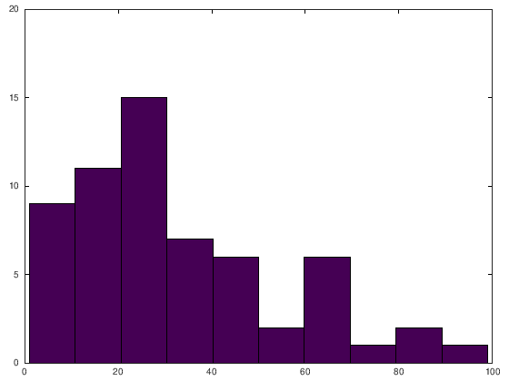

```matlab
hist(notlar)
```

Birazcık daha anlaşılır kılalım:

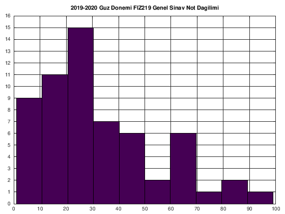

```matlab
hist(notlar)
xticks(0:10:100)
yticks(0:20)
title("2019-2020 Guz Donemi FIZ219 Genel Sinav Not Dagilimi")
grid on
```

Grafiğe bakarak kolayca (0,10] aralığında 9 not olduğunu, (10,20] arasında 11 not olduğunu, vs. görebiliyoruz, ki zaten histogramın amacı da budur.

`hist` fonksiyonu varayılan olarak, verileri 10 kutuda toplar. İkinci bir paremetre ile kutu sayısını da belirleyebiliriz:

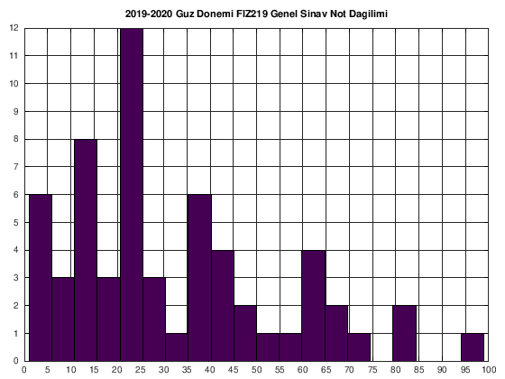

```matlab
hist(notlar,20)
xticks(0:5:100)
yticks(0:20)
title("2019-2020 Guz Donemi FIZ219 Genel Sinav Not Dagilimi")
grid on
```

`hist()` fonksiyonu ve parametreleri hakkında daha fazla bilgiyi [Octave'ın ilgili kılavuz sayfasında](https://octave.sourceforge.io/octave/function/hist.html) bulabilirsiniz.

# 3 Boyutlu Çizimler

Nihayet en süper görünen çizimlere gelebildik! Ama işin kod kısmına geçmeden önce, 3 boyutlu çizimin ne anlama geldiğini tartışalım biraz. 3 boyutlu çizimlerde, $f(x,y,z)$ gibi 3 parametreli fonksiyonların grafikleri çizilmez (o 4 boyutlu bir uzay gerektiriyor maalesef), $f(x,y)$ gibi 2 parametreli fonksiyonların grafikleri çizilir.

Kareli bir kağıt alıp, kesişim noktalarına pozitif veya negatif, çeşitli değerler yazdığınızı düşünün. Sonrasında her noktayı üzerinde yazan değer kadar pozitifse yukarı kaldırdığınızı, negatifse aşağı çektiğinizi varsayın -- işte 3 boyutlu grafik böyle bir şey.

Örneğin, 2x2'lik bir matrisin 9 köşesini aşağıdaki gibi işaretlediğimizi (indislediğimizi) düşünelim:

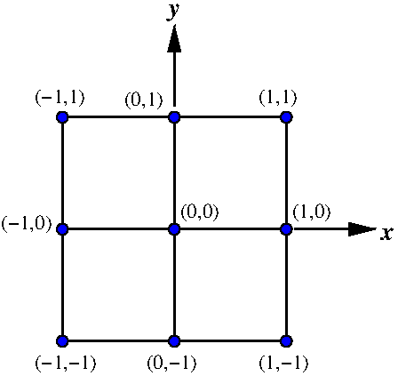

(Köşelerin koordinatlarını (indislerini) iyice inceleyin, aklınıza yatsın)

Şimdi de, her bir köşenin "z" değerini koordinatlarının karesinin toplamı olarak yazalım. Örneğin (0,-1) noktasının değeri: $0^2+(-1)^2 = 1$ olur. Her köşenin yanına bu değerleri de yazalım:

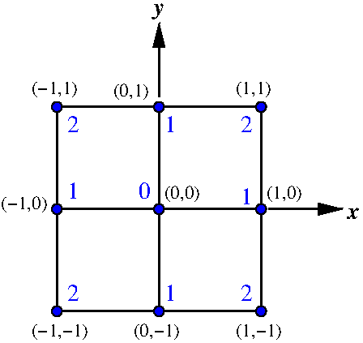

3 boyutlu grafik çizerken de tam olarak benzer bir süreçten geçiyoruz. Öncelikle, $x=\{-1,0,1\}$ değerleri ile $y=\{-1,0,1\}$ değerlerini harmanlayıp, (-1,-1)'den (1,1)'e olası 9 kombinasyonu üreteceğiz, sonrasında da bu koordinatlara karşılık gelen değer olarak indislerin karelerin toplamını atayacağız.

Önce harmanlama işini yapalım, bunu `meshgrid()` fonksiyonu ile gerçekleştiriyoruz:

```matlab
tx = linspace(-1,1,3)
ty = linspace(-1,1,3)
[xx,yy] = meshgrid(tx,ty)
```

```
tx =

  -1   0   1

ty =

  -1   0   1

xx =

  -1   0   1
  -1   0   1
  -1   0   1

yy =

  -1  -1  -1
   0   0   0
   1   1   1
```

Biz `tx` ile `ty` değişkenlerini tanım aralığımız olarak tanımlıyoruz, meshgrid de bunları öyle bir harmanlıyor ki, ürettiği `xx` ile `yy` üst üste bindirirsek, tam olarak yukarıdaki koordinat sistemi ortaya çıkıyor. 8)

Şimdi de her bir koordinatın değerini koordinatlarının karesi olarak tanımlayalım:

```matlab
tz = xx.^2 + yy.^2
```

```
tz =

   2   1   2
   1   0   1
   2   1   2
```

İyi gidiyoruz, az da kaldı... Şimdi değerleri "1" olan ortaları 1 birim; değerleri "2" olan köşeleri ise 2 birim yukarı kaldırırken, orta noktayı "0" olan değerinden ötürü, masanın seviyesine raptiye ile tutturduğumuzu düşünelim. Görüntüyü kafanızda canlandırabildiniz mi? Şuna benziyor mu?:

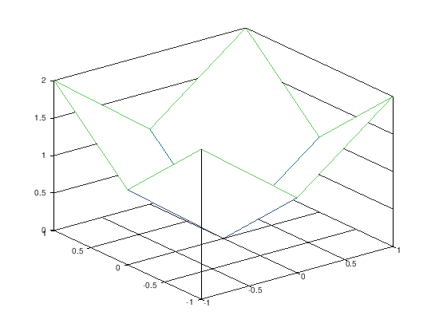

```matlab
mesh(tx,ty,tz)
```

Elinizi korkak alıştırmayın, tutun ucundan, döndürün, çevirin, ilk üç boyutlu grafiğiniz hayırlı olsun, tadını çıkarın! 8)

Kafamızda rahat canlandırabilelim diye 3x3 = 9 noktada çizdirdik ama tabii ki bu epey kaba bir grafik oldu, biz her eksende 100 nokta alalım (yani ağımız (*meshgrid*) 100x100 = 10000 köşe olsun):

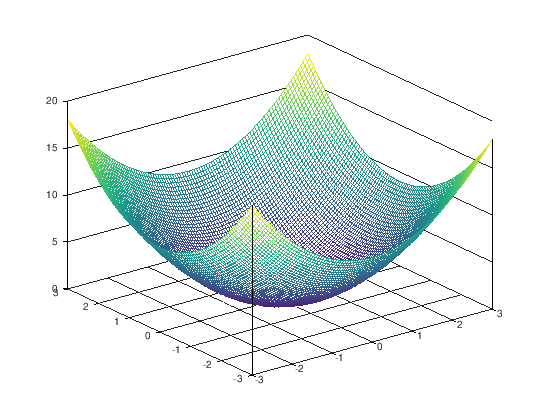

```matlab
tx=ty=linspace(-3,3,100);
[xx,yy] = meshgrid(tx,ty);
tz = xx.^2+yy.^2;
mesh(tx,ty,tz)
```

2 boyutlu grafiklerde yaptığımız gibi, 2 boyutlu grafiklerde de açıklayıcı bilgiler girebiliriz:

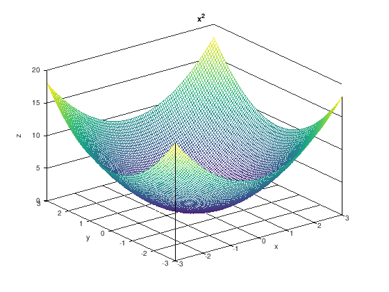

```matlab
mesh(tx,ty,tz);
xlabel ("x");
ylabel ("y");
zlabel ("z");
title ("x^2");
```

Ya da dilersek, 3 boyutlu çizimin altına iki boyuttaki izdüşümü olan kontür haritasını da ekleyebiliriz. Bunun için `mesh` fonksiyonunu değil de `meshc` fonksiyonunu kullanıyoruz:

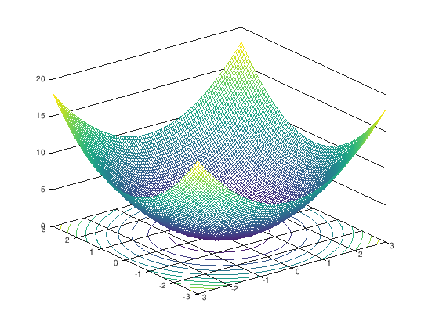

```matlab
meshc(tx,ty,tz);
```

sadece kontür haritasını çizdirmek içinse `contour()` fonksiyonu var:

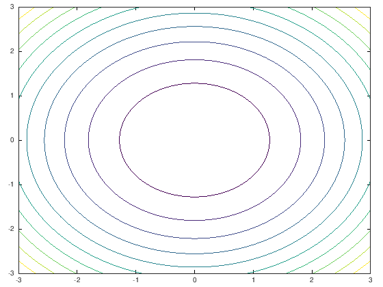

```matlab
contour(tx,ty,tz)
```

3-boyutlu grafikte dikkat ederseniz sadece tel var, yani ağların arası açık gibi. Ağ yerine yüzey varmış da, onu bükmüşüz gibi olsun istersek `surf()` fonksiyonu devreye giriyor:

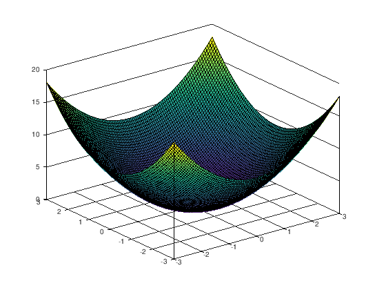

```matlab
surf(tx,ty,tz);
```

`surf`'ün de `mesh` gibi, kontür haritalı versiyonu var: `surfc()`:

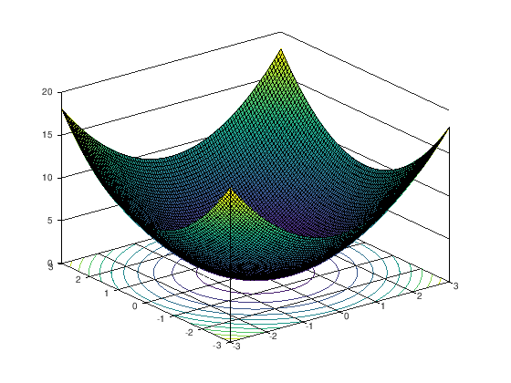

```matlab
surfc(tx,ty,tz);
```

# Grafikleri dosyaya yazdırma

Aktif grafiği bir dosyaya aktarmak için, `print` komutunu kullanırız:

`print -d{biçim} {dosya_adı}` şeklinde. Biçim, png olur, pdf, jpg, gif, ps, eps...; dosya adı size kalmış ama uyumluluk açısından boşluksuz, Türkçe karakter olmasını tavsiye ederim.

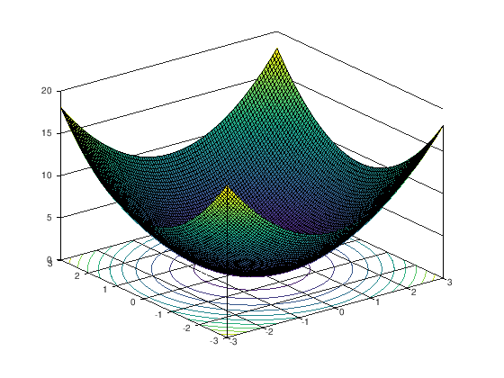

```matlab
surfc(tx,ty,tz);
print -dpng "3D_Grafik.png"
```

Grafiğimizi yukarıdaki komutla "3D_Grafik.png" dosyasına yazdık ama acaba o dosya nerede? Tabii ki Octave hangi klasörü çalışma klasörü olarak aldıysa orada... Peki o klasörün o anda hangi klasör olduğunu nasıl anlarız? "Print Working Directory" (*Çalışma klasörünü yazdır*) komutunun baş harfleri olan `pwd` komutuyla! 8)

```matlab
pwd
```

```
ans = /home/sururi/ownCloud/Jupyter_notebooks/FIZ219
```

# Kaynakça

- [Octave, High-Level Plotting](https://octave.org/doc/v4.2.1/High_002dLevel-Plotting.html#High_002dLevel-Plotting)